DS 6030 | Fall 2024 | University of Virginia

# Homework #6: SVM and Calibration

Author

**Ashley Miller**

Published

October 22, 2024

# Required R packages and Directories

```r
dir_data= 'https://mdporter.github.io/teaching/data/' # data directory
library(tidyverse)  # functions for data manipulation
library(skimr)
library(pROC)
```

# COMPAS Recidivism Prediction

A recidivism risk model called COMPAS was the topic of a [ProPublica article](https://www.propublica.org/article/machine-bias-risk-assessments-in-criminal-sentencing/) on ML bias. Because the data and notebooks used for article was released on [github](https://github.com/propublica/compas-analysis), we can also evaluate the prediction bias (i.e., calibration).

This code will read in the *violent crime* risk score and apply the filtering used in the [analysis](https://github.com/propublica/compas-analysis/blob/master/Compas%20Analysis.ipynb).

```r
library(tidyverse)
df = read_csv("https://raw.githubusercontent.com/propublica/compas-analysis/master/compas-scores-two-years-violent.csv")

risk = df %>%
  filter(days_b_screening_arrest <= 30) %>%
  filter(days_b_screening_arrest >= -30) %>%
  filter(is_recid != -1) %>%
  filter(c_charge_degree != "O") %>%
  filter(v_score_text != 'N/A') %>%
  transmute(
    age, age_cat,
    charge = ifelse(c_charge_degree == "F", "Felony", "Misdemeanor"),
    race,
    sex,
    priors_count = priors_count...15,
    score = v_decile_score,              # the risk score {1,2,...,10}
    outcome = two_year_recid...53        # outcome {1 = two year recidivate}
  )
```

```r
skim(risk)
```

Data summary

| Name | risk |
| --- | --- |
| Number of rows | 4020 |
| Number of columns | 8 |
| _______________________ |  |
| Column type frequency: |  |
| character | 4 |
| numeric | 4 |
| ________________________ |  |
| Group variables | None |

**Variable type: character**

| skim_variable | n_missing | complete_rate | min | max | empty | n_unique | whitespace |
| --- | --- | --- | --- | --- | --- | --- | --- |
| age_cat | 0 | 1 | 7 | 15 | 0 | 3 | 0 |
| charge | 0 | 1 | 6 | 11 | 0 | 2 | 0 |
| race | 0 | 1 | 5 | 16 | 0 | 6 | 0 |
| sex | 0 | 1 | 4 | 6 | 0 | 2 | 0 |

**Variable type: numeric**

| skim_variable | n_missing | complete_rate | mean | sd | p0 | p25 | p50 | p75 | p100 | hist |
| --- | --- | --- | --- | --- | --- | --- | --- | --- | --- | --- |
| age | 0 | 1 | 35.74 | 12.07 | 18 | 26 | 33 | 44 | 83 | ▇▅▃▁▁ |
| priors_count | 0 | 1 | 2.45 | 3.95 | 0 | 0 | 1 | 3 | 38 | ▇▁▁▁▁ |
| score | 0 | 1 | 3.27 | 2.37 | 1 | 1 | 3 | 5 | 10 | ▇▃▂▁▁ |
| outcome | 0 | 1 | 0.16 | 0.37 | 0 | 0 | 0 | 0 | 1 | ▇▁▁▁▂ |

The `risk` data frame has the relevant information for completing the problems.

# Problem 1: COMPAS risk score

## a. Risk Score and Probability (table)

Assess the predictive bias in the COMPAS risk scores by evaluating the probability of recidivism, e.g. estimate $\Pr(Y = 1 \mid \text{Score}=x)$. Use any reasonable techniques (including Bayesian) to estimate the probability of recidivism for each risk score.

Specifically, create a table (e.g., data frame) that provides the following information:

- The COMPASS risk score.
- The point estimate of the probability of recidivism for each risk score.
- 95% confidence or credible intervals for the probability (e.g., Using normal theory, bootstrap, or Bayesian techniques).

Indicate the choices you made in estimation (e.g., state the prior if you used Bayesian methods).

**Solution**

```r
library(brms)
priors <- c(set_prior("normal(0, 100)", class = "b"), # chosen to be less sure than the intercept
           set_prior("normal(0, 10)", class = "Intercept") # fairly sure the intercept should be near 0
)

bayesian_model <- brm(outcome ~ score, data = risk, family = bernoulli,
                      prior = priors, seed = 666)
prior_summary(bayesian_model)
```

```
          prior     class  coef group resp dpar nlpar lb ub       source
 normal(0, 100)         b                                           user
 normal(0, 100)         b score                             (vectorized)
  normal(0, 10) Intercept                                           user
```

```r
summary(bayesian_model)
```

```
 Family: bernoulli
  Links: mu = logit
Formula: outcome ~ score
   Data: risk (Number of observations: 4020)
  Draws: 4 chains, each with iter = 2000; warmup = 1000; thin = 1;
         total post-warmup draws = 4000

Regression Coefficients:
          Estimate Est.Error l-95% CI u-95% CI Rhat Bulk_ESS Tail_ESS
Intercept    -2.89      0.09    -3.06    -2.72 1.00     2053     2157
score         0.32      0.02     0.29     0.36 1.00     2519     2422

Draws were sampled using sampling(NUTS). For each parameter, Bulk_ESS
and Tail_ESS are effective sample size measures, and Rhat is the potential
scale reduction factor on split chains (at convergence, Rhat = 1).
```

```r
posterior_samples <- as_draws_df(bayesian_model, variable =  c("b_Intercept", "b_score"))
posterior_samples <- as.data.frame(posterior_samples)

recid_pr <- rep(NA, 10)
ci_lower <- rep(NA, 10)
ci_upper <- rep(NA, 10)

for (i in 1:10) {
  recid_pr[i] <- mean(inv_logit_scaled(posterior_samples$b_Intercept + posterior_samples$b_score * i))
  ci <- quantile(inv_logit_scaled(posterior_samples$b_Intercept + posterior_samples$b_score * i), c(0.025, 0.975))
  ci_lower[i] <- ci[1]
  ci_upper[i] <- ci[2]
}

comp <- tibble(
  risk_score = 1:10,
  recid_pr = recid_pr,
  ci_lower = ci_lower,
  ci_upper = ci_upper
)
```

## b. Risk Score and Probability (plot)

Make a plot of the risk scores and corresponding estimated probability of recidivism.

- Put the risk score on the x-axis and estimate probability of recidivism on y-axis.
- Add the 95% confidence or credible intervals calculated in part a.
- Comment on the patterns you see.

**Solution**

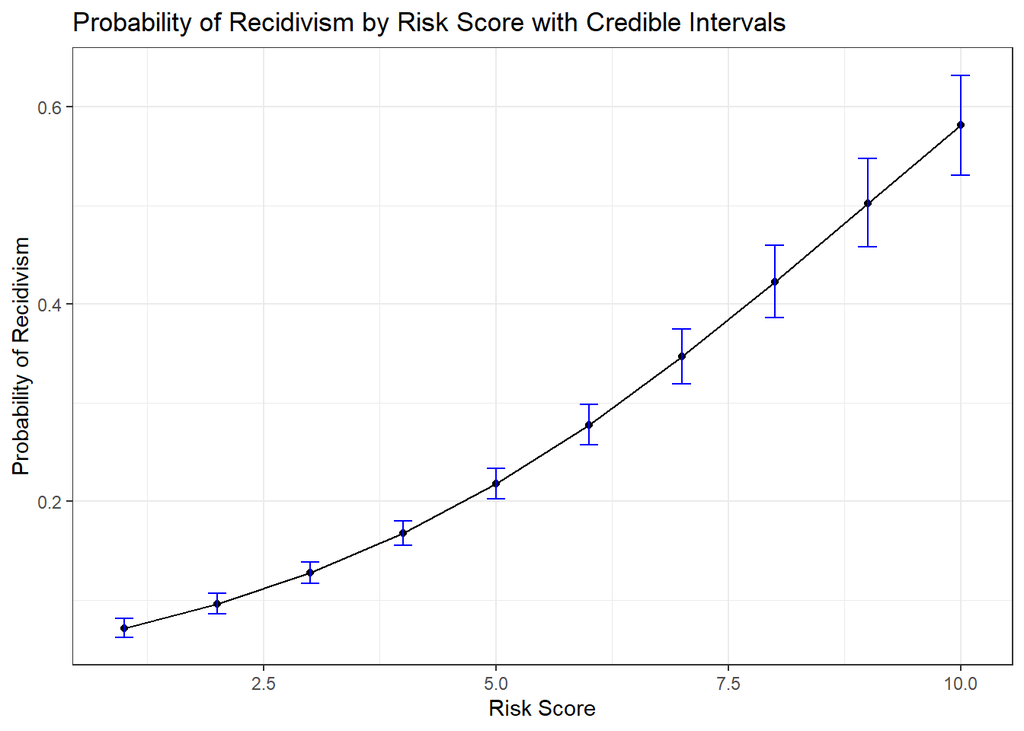

```r
comp %>%
  ggplot(aes(x=risk_score, y=recid_pr)) +
  geom_point() +
  geom_line() +
  geom_errorbar(aes(ymin = ci_lower, ymax = ci_upper), width = 0.2, color = "blue") +
  labs(
    title = "Probability of Recidivism by Risk Score with Credible Intervals",
    x = "Risk Score",
    y = "Probability of Recidivism"
  )
```

The probability of recidivism goes up as the risk score increases, but the credible intervals also widen as the risk score increases.

## c. Risk Score and Probability (by race)

Repeat the analysis, but this time do so for every race. Produce a set of plots (one per race) and comment on the patterns.

**Solution**

```r
split_data <- risk %>% group_by(race) %>% group_split()

models <- lapply(split_data, function(df) {
  brm(outcome ~ score, data = df, family = bernoulli,
                      prior = priors, seed = 666)
})
```

[figure not shown]

[figure not shown]

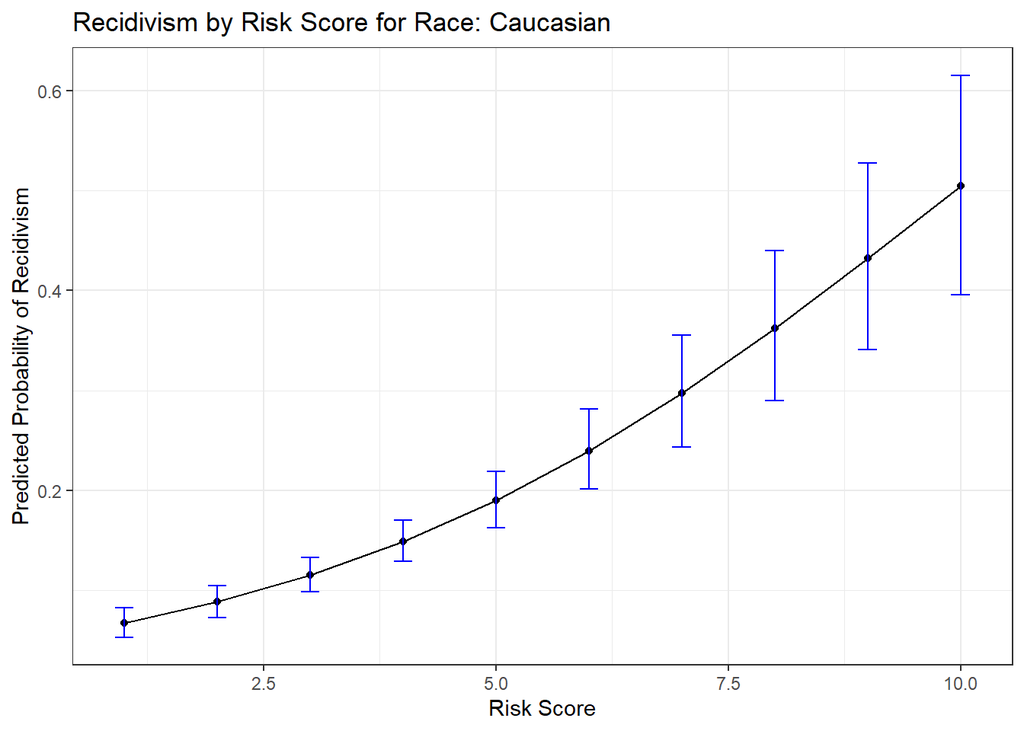

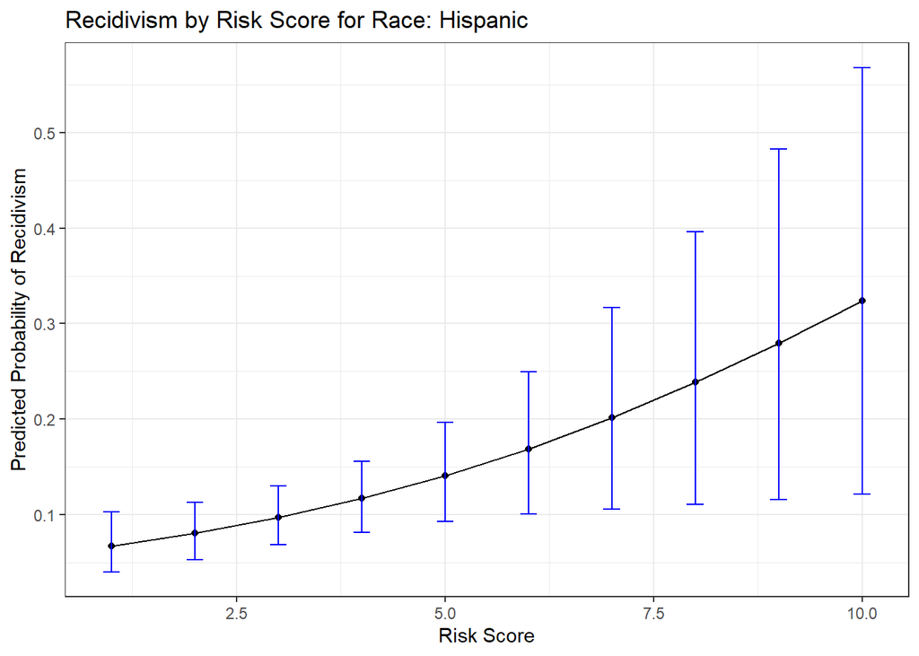

[figure not shown]

[figure not shown]

```r
model_names <- unique(risk$race)

for (i in 1:length(models)) {
  posterior_samples <- as_draws_df(models[[i]], variable = c("b_Intercept", "b_score"))
  posterior_samples <- as.data.frame(posterior_samples)

  recid_pr <- rep(NA, 10)
  ci_lower <- rep(NA, 10)
  ci_upper <- rep(NA, 10)

  for (j in 1:10) {
    logit_vals <- posterior_samples$b_Intercept + posterior_samples$b_score * j
    recid_pr[j] <- mean(inv_logit_scaled(logit_vals))
    ci <- quantile(inv_logit_scaled(logit_vals), c(0.025, 0.975))
    ci_lower[j] <- ci[1]
    ci_upper[j] <- ci[2]
  }

  comp <- tibble(
    risk_score = 1:10,
    recid_pr = recid_pr,
    ci_lower = ci_lower,
    ci_upper = ci_upper
  )

  plot <- ggplot(comp, aes(x = risk_score, y = recid_pr)) +
    geom_line() +
    geom_point() +
    geom_errorbar(aes(ymin = ci_lower, ymax = ci_upper), width = 0.2, color = "blue") +
    labs(
      title = paste("Recidivism by Risk Score for Race:", model_names[i]),
      x = "Risk Score",
      y = "Predicted Probability of Recidivism"
    )

  print(plot)
}
```

## d. ROC Curves

Use the raw COMPAS risk scores to make a ROC curve for each race.

- Are the best discriminating models the ones you expected?
- Are the ROC curves helpful in evaluating the COMPAS risk score?

**Solution**

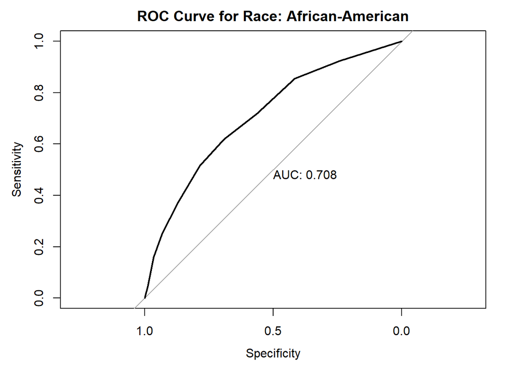

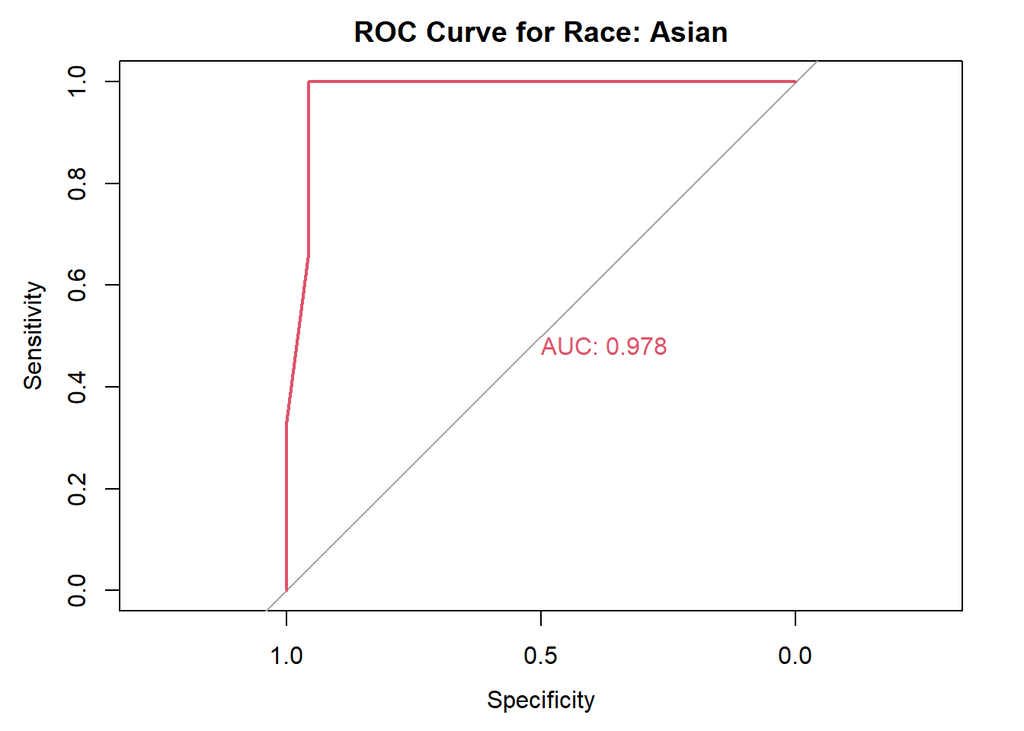

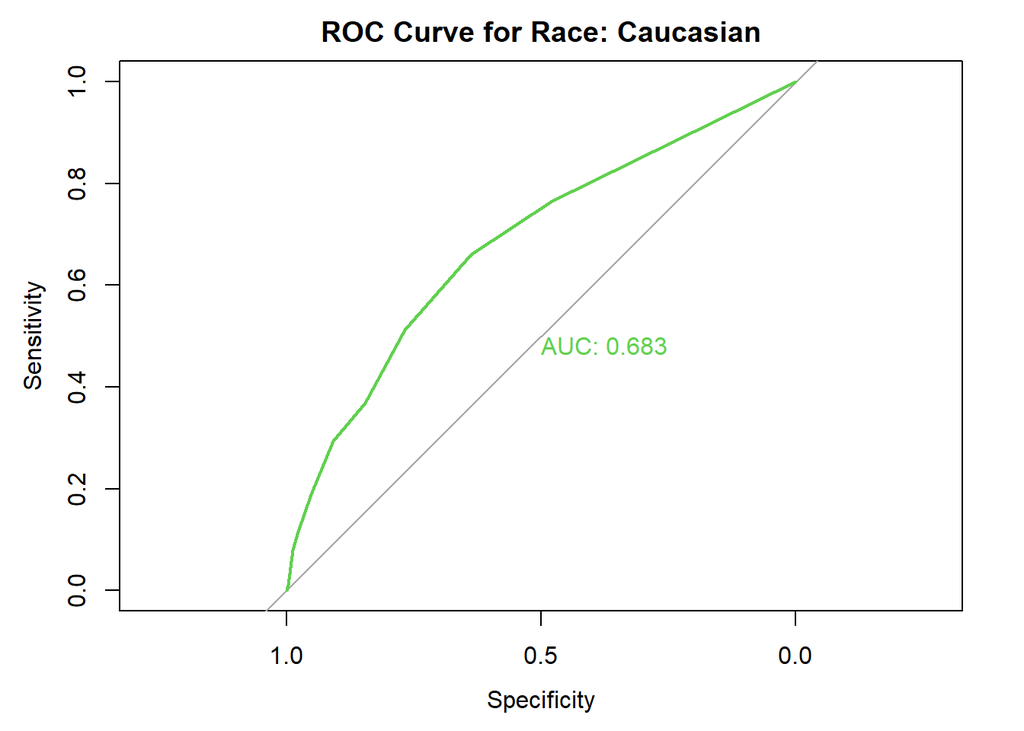

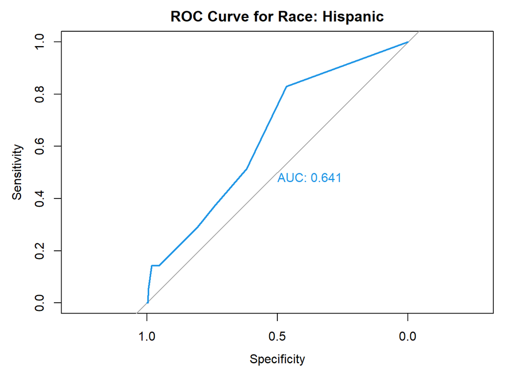

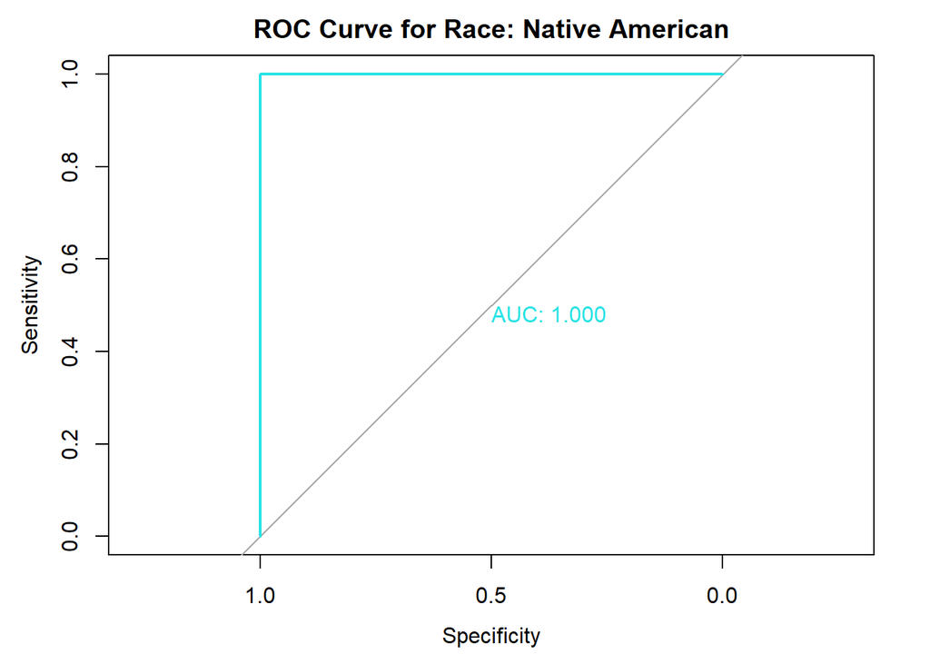

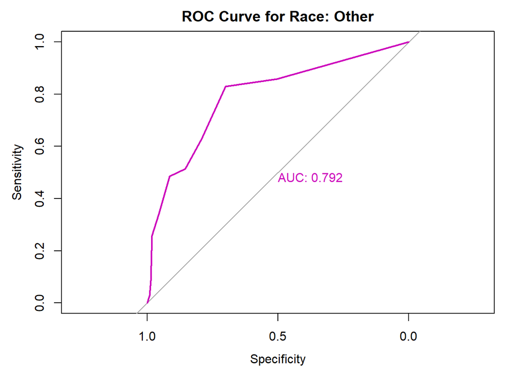

```r
roc_curves <- list()

for (i in 1:length(split_data)) {
  race_data <- split_data[[i]]
  race_name <- unique(race_data$race)

  roc_curve <- roc(race_data$outcome, race_data$score)
  roc_curves[[race_name]] <- roc_curve

  plot(roc_curve, main = paste("ROC Curve for Race:", race_name),
       col = i, lwd = 2, print.auc = TRUE)
}
```

# Problem 2: Support Vector Machines (SVM)

Focus on Problem 1, we won’t have an SVM problem this week.